# SI 618 Day 10: Clustering In-class Exercises

### Dr. Chris Teplovs, School of Information, University of Michigan

Copyright © 2024. This notebook may not be shared outside of the course without permission.

### Please ensure you have this version:

Version 2024.10.31.3.CT

## A few words about pipelines

Consider the following pipeline:

```python
from sklearn.pipeline import Pipeline
from sklearn.preprocessing import StandardScaler
from sklearn.decomposition import PCA
from sklearn.manifold import MDS

pipe = Pipeline(
    [
    ('scale',StandardScaler()),
    ('pca', PCA(n_components=5,random_state=42)),
    ]
)
```

The pipeline can be queried by using `get_params()`:

```python
pipe.get_params()
```

```
{'memory': None,
 'steps': [('scale', StandardScaler()),
  ('pca', PCA(n_components=5, random_state=42))],
 'verbose': False,
 'scale': StandardScaler(),
 'pca': PCA(n_components=5, random_state=42),
 'scale__copy': True,
 'scale__with_mean': True,
 'scale__with_std': True,
 'pca__copy': True,
 'pca__iterated_power': 'auto',
 'pca__n_components': 5,
 'pca__n_oversamples': 10,
 'pca__power_iteration_normalizer': 'auto',
 'pca__random_state': 42,
 'pca__svd_solver': 'auto',
 'pca__tol': 0.0,
 'pca__whiten': False}
```

The `named_steps` attribute holds (unsurprisingly) the named steps of the pipeline:

```python
pipe.named_steps
```

```
{'scale': StandardScaler(), 'pca': PCA(n_components=5, random_state=42)}
```

The steps themselves can be accessed as attributes of the `named_steps` property:

```python
pipe.named_steps.pca
```

```
PCA(n_components=5, random_state=42)
```

And specifics about the step can be modified by assigning new values to them:

```python
pipe.named_steps.pca.n_components=3
```

```python
pipe.named_steps.pca
```

[output not shown]

And you can also use the __ syntax:

```python
pipe.set_params(pca__n_components=2)
```

```
Pipeline(steps=[('scale', StandardScaler()),
                ('pca', PCA(n_components=2, random_state=42))])
```

```python
import pandas as pd
```

```python
x = pd.DataFrame({'a':[1,2,3],'b':[4,15,6]})
```

```python
x
```

|  | a | b |
| --- | --- | --- |
| 0 | 1 | 4 |
| 1 | 2 | 15 |
| 2 | 3 | 6 |

```python
pipe.fit_transform(x)
```

```
array([[-1.50648943, -0.22556137],
       [ 0.98532928, -0.98532928],
       [ 0.52116016,  1.21089065]])
```

```python
pipe.named_steps.pca.explained_variance_ratio_
```

```
array([0.58533202, 0.41466798])
```

Ok, on to today's notebook, which consists of two tasks. First, let's load the music data we generated in an earlier class:

```python
import pandas as pd
import numpy as np
import seaborn as sns
```

```python
url = "https://docs.google.com/spreadsheets/d/e/2PACX-1vTnvfFzQRzibiGd92rL2UvolprozD3BtqlhzYb8EhA3gdoYEKYrDfoNa1p7sdQZTg4fYJ6VOrZnD4mU/pub?gid=0&single=true&output=csv"
music = pd.read_csv(url)
```

```python
# let's use these imports to make life easier

from sklearn.cluster import KMeans
from sklearn.cluster import AgglomerativeClustering
from sklearn.preprocessing import StandardScaler
from sklearn.impute import SimpleImputer
```

```python
music.info()
```

```
<class 'pandas.core.frame.DataFrame'>
RangeIndex: 46 entries, 0 to 45
Data columns (total 11 columns):
 #   Column      Non-Null Count  Dtype
---  ------      --------------  -----
 0   Name        46 non-null     object
 1   Blues       46 non-null     int64
 2   Classical   46 non-null     int64
 3   Country     46 non-null     int64
 4   Electronic  46 non-null     int64
 5   Folk        46 non-null     int64
 6   Hip Hop     46 non-null     int64
 7   Jazz        46 non-null     int64
 8   Latin       46 non-null     int64
 9   Pop         46 non-null     int64
 10  Rock        46 non-null     int64
dtypes: int64(10), object(1)
memory usage: 4.1+ KB
```

```python
music.sample(5)
```

|  | Name | Blues | Classical | Country | Electronic | Folk | Hip Hop | Jazz | Latin | Pop | Rock |
| --- | --- | --- | --- | --- | --- | --- | --- | --- | --- | --- | --- |
| 39 | Ruizhe Wang | 3 | 5 | 6 | 7 | 7 | 5 | 3 | 2 | 7 | 9 |
| 27 | Michael G | 7 | 5 | 5 | 7 | 4 | 2 | 8 | 4 | 4 | 8 |
| 28 | Boqian | 4 | 4 | 2 | 7 | 1 | 7 | 7 | 2 | 8 | 8 |
| 29 | Nida K | 1 | 6 | 6 | 4 | 7 | 8 | 5 | 8 | 9 | 8 |
| 15 | Yidan C. | 5 | 7 | 7 | 4 | 6 | 4 | 8 | 3 | 6 | 9 |

## Task

Create a feature dataframe and a labels dataframe from the music dataframe. Assign them to `X` and `y`, respectively (note the use of uppercase X and lowercase y).

```python
y = music['Name']
X = music.drop(columns=['Name'])
```

## Challenge 1:

Write code that does the following:

1. Fills NA values with 1
2. Scales each variable to mean=0 and variance=1
3. Uses PCA to reduce the number of dimensions to 3; make sure you set random_state to some constant to allow you to reproduce your results
4. Uses the PCA projections (i.e. the transformed X matrix) as input to agglomerative clustering

Report the percent variance that is retained in the 3-dimensional PCA.

Create a visualization of the resulting clustering (i.e. create a dendrogram). Annotate the visulization with a horizontal line that "cuts" the tree at a reasonable level and provide a written summary of each cluster's membership. Save the resulting dendrogram to a PDF file called 'music_clusters.pdf' (hint: use `plt.savefig()`)

```python
from sklearn.pipeline import Pipeline
from sklearn.preprocessing import StandardScaler
from sklearn.decomposition import PCA
from sklearn.impute import SimpleImputer
from sklearn.cluster import AgglomerativeClustering
from scipy.cluster.hierarchy import dendrogram
from sklearn.cluster import KMeans
from sklearn.metrics import silhouette_samples, silhouette_score
import matplotlib.pyplot as plt
import matplotlib.cm as cm # colormaps
```

```python
# Authors: Mathew Kallada & Chris Teplovs
# License: BSD 3 clause
"""
=========================================
Plot Hierarachical Clustering Dendrogram
=========================================
This example plots the corresponding dendrogram of a hierarchical clustering
using AgglomerativeClustering and the dendrogram method available in scipy.
"""

def plot_dendrogram(model, **kwargs):

    # Children of hierarchical clustering
    children = model.children_

    # Distances between each pair of children
    # Since we don't have this information, we can use a uniform one for plotting
    distance = np.arange(children.shape[0])

    # The number of observations contained in each cluster level
    no_of_observations = np.arange(2, children.shape[0]+2)

    # Create linkage matrix and then plot the dendrogram
    linkage_matrix = np.column_stack([children, distance, no_of_observations]).astype(float)

    # Plot the corresponding dendrogram
    dendrogram(linkage_matrix, **kwargs)

    plt.axhline(y=kwargs['color_threshold'], color='black', linestyle='--')

    plt.savefig('music_cluster.pdf')
```

```python
# define the pipeline
pipe = Pipeline([
    ('imputer', SimpleImputer(strategy='constant', fill_value=1)),
    ('scale', StandardScaler()),
    ('pca', PCA(n_components=5, random_state=42)),
])
```

```python
data_transformed = pipe.fit_transform(X)

cluster = AgglomerativeClustering(n_clusters=3)
cluster.fit(data_transformed)

# Report the explained variance ratio and total explained variance
exp_ratio = pipe.named_steps.pca.explained_variance_ratio_
total_exp = np.sum(exp_ratio)
print(f"Explained variance ratio: {exp_ratio}")
print(f"Total explained variance: {total_exp}")
```

```
Explained variance ratio: [0.22670131 0.17051591 0.15004657 0.10505937 0.09410194]
Total explained variance: 0.7464251001493356
```

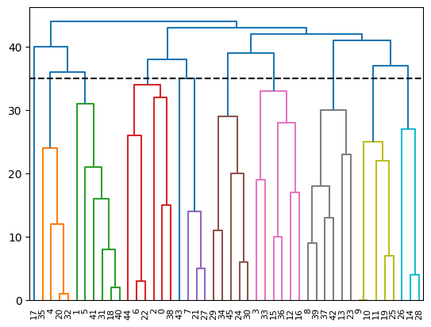

```python
# Plot the dendrogram
plot_dendrogram(cluster, color_threshold=35)
```

## Challenge 2

Conduct a k-means clustering of the music data. Preprocess the data by scaling it and performing a PCA and retaining 2 dimensions. Use the PCA scores as input to the clustering. Use silhouette plots to determine the optimal number of clusters. Be sure to provide a written interpretation of your silhouette plots.

If time permits, experiment with changing the number of principal components. Be sure to set your random_state to allow you to reproduce your results.

Note that you do not need to use a pipeline, although doing so may make your life easier.

```python
pipe.named_steps.pca.n_components=2

data_transformed = pipe.fit_transform(X)

kmeans = KMeans(n_clusters=3, random_state=42)
kmeans.fit(data_transformed)
y_kmeans = kmeans.predict(data_transformed)
silhouette_score(data_transformed, y_kmeans)
```

```
np.float64(0.36105808172037596)
```

```
For n_clusters = 2 The average silhouette_score is : 0.3704898836945992
For n_clusters = 3 The average silhouette_score is : 0.36105808172037596
For n_clusters = 4 The average silhouette_score is : 0.3852066676442209
For n_clusters = 5 The average silhouette_score is : 0.337366604577418
For n_clusters = 6 The average silhouette_score is : 0.355293449436642
```

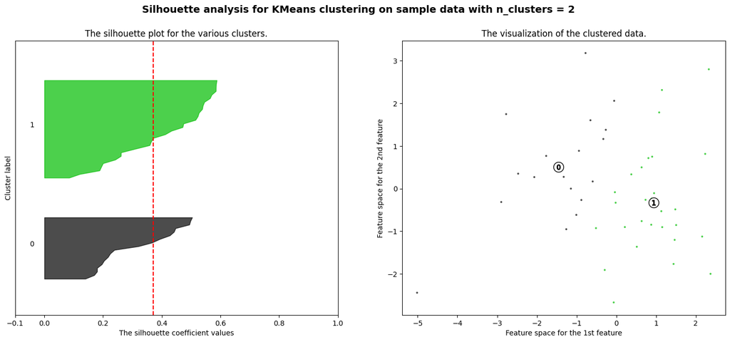

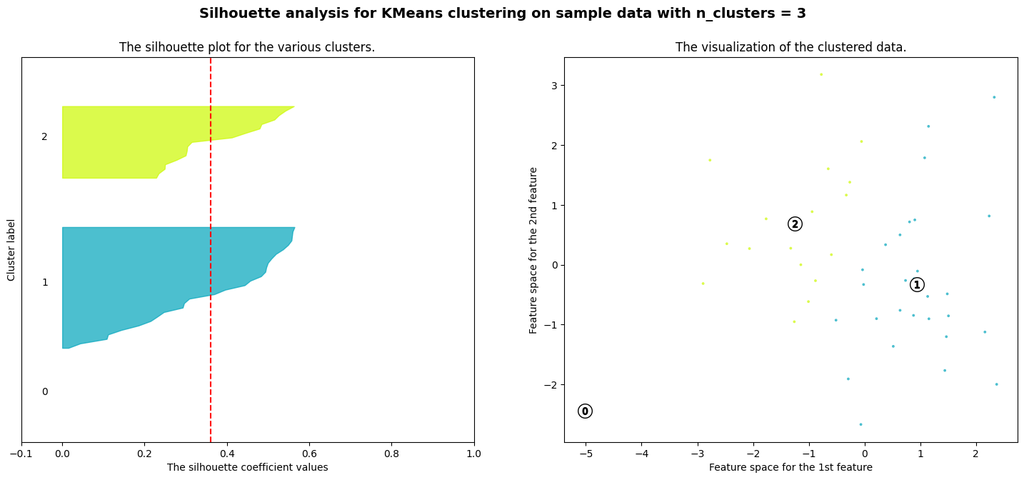

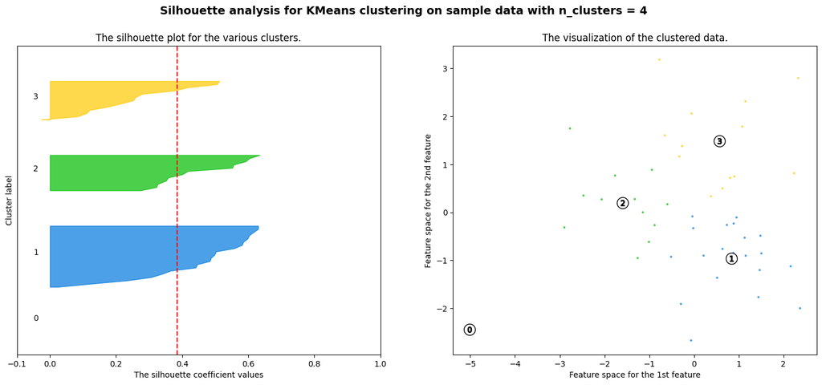

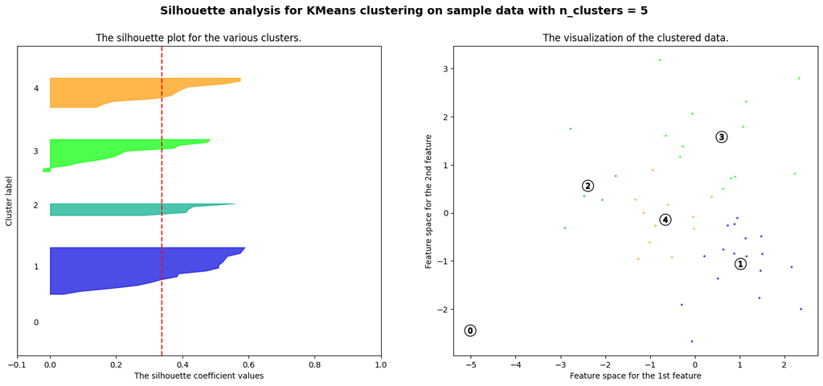

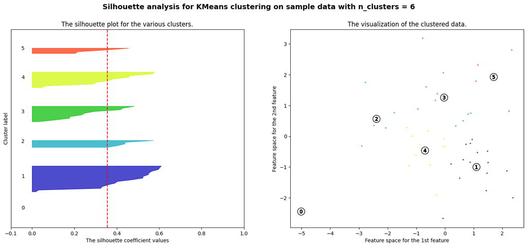

```python
# Try clusters from 2 to 5
range_n_clusters = [2, 3, 4, 5, 6]

for n_clusters in range_n_clusters:
    # Create a subplot with 1 row and 2 columns
    fig, (ax1, ax2) = plt.subplots(1, 2)
    fig.set_size_inches(18, 7)

    # The 1st subplot is the silhouette plot
    # The silhouette coefficient can range from -1, 1 but in this example all
    # lie within [-0.1, 1]
    ax1.set_xlim([-0.1, 1])
    # The (n_clusters+1)*10 is for inserting blank space between silhouette
    # plots of individual clusters, to demarcate them clearly.
    ax1.set_ylim([0, len(X) + (n_clusters + 1) * 10])

    # Initialize the clusterer with n_clusters value and a random generator
    # seed of 42 for reproducibility.
    clusterer = KMeans(n_clusters=n_clusters, n_init="auto", random_state=42)
    cluster_labels = clusterer.fit_predict(data_transformed)

    # The silhouette_score gives the average value for all the samples.
    # This gives a perspective into the density and separation of the formed
    # clusters
    silhouette_avg = silhouette_score(data_transformed, cluster_labels)
    print("For n_clusters =", n_clusters,
        "The average silhouette_score is :", silhouette_avg)

    # Compute the silhouette scores for each sample
    sample_silhouette_values = silhouette_samples(data_transformed, cluster_labels)

    y_lower = 10
    for i in range(n_clusters):
        # Aggregate the silhouette scores for samples belonging to
        # cluster i, and sort them
        ith_cluster_silhouette_values = sample_silhouette_values[cluster_labels == i]

        ith_cluster_silhouette_values.sort()

        size_cluster_i = ith_cluster_silhouette_values.shape[0]
        y_upper = y_lower + size_cluster_i

        color = cm.nipy_spectral(float(i) / n_clusters)
        ax1.fill_betweenx(np.arange(y_lower, y_upper),
                        0, ith_cluster_silhouette_values,
                        facecolor=color, edgecolor=color, alpha=0.7)

        # Label the silhouette plots with their cluster numbers at the middle
        ax1.text(-0.05, y_lower + 0.5 * size_cluster_i, str(i))

        # Compute the new y_lower for next plot
        y_lower = y_upper + 10  # 10 for the 0 samples

    ax1.set_title("The silhouette plot for the various clusters.")
    ax1.set_xlabel("The silhouette coefficient values")
    ax1.set_ylabel("Cluster label")

    # The vertical line for average silhouette score of all the values
    ax1.axvline(x=silhouette_avg, color="red", linestyle="--")

    ax1.set_yticks([])  # Clear the yaxis labels / ticks
    ax1.set_xticks([-0.1, 0, 0.2, 0.4, 0.6, 0.8, 1])

    # 2nd Plot showing the actual clusters formed
    colors = cm.nipy_spectral(cluster_labels.astype(float) / n_clusters)
    ax2.scatter(data_transformed[:, 0], data_transformed[:, 1], marker='.', s=30, lw=0, alpha=0.7,
                c=colors, edgecolor='k')

    # Labeling the clusters
    centers = clusterer.cluster_centers_
    # Draw white circles at cluster centers
    ax2.scatter(centers[:, 0], centers[:, 1], marker='o',
                c="white", alpha=1, s=200, edgecolor='k')

    for i, c in enumerate(centers):
        ax2.scatter(c[0], c[1], marker='$%d$' % i, alpha=1,
                    s=50, edgecolor='k')

    ax2.set_title("The visualization of the clustered data.")
    ax2.set_xlabel("Feature space for the 1st feature")
    ax2.set_ylabel("Feature space for the 2nd feature")

    plt.suptitle(("Silhouette analysis for KMeans clustering on sample data "
                  "with n_clusters = %d" % n_clusters),
                 fontsize=14, fontweight='bold')

plt.show()
```

I tried 2 to 6 clusters to fit K-means see how the clusters change. However, the silhouette scores did not change pretty much. Especially when the number of clusters are higher, K-means does not work really well. I would prefer the 3 clusters solution, though there are one cluster which only contains one member.

# Please remember to submit your notebook in IPYNB and HTML format.